# Linear Models

Jiaxin Zheng A0266129Y

2025-04-10

```r
library(dplyr)
```

```r
library(ggplot2)
library(lubridate)
library(readr)
library(stringr)
library(ggpubr)
library(corrplot)
library(car)
library(MASS)
library(splines)
library(boot)
library(mgcv)
```

For linear models, R will automatically deal with categorical variable. However, for numerical values, we try to scale them to avoid the dominant affect of those with high numeric values.

```r
df_clean <- read.csv("../data/df_clean.csv")
head(df_clean)
```

```
##   X      month       town flat_type floor_area_sqm lease_commence_date
## 1 1 2017-01-01 ANG MO KIO    2 ROOM             44                1979
## 2 2 2017-01-01 ANG MO KIO    3 ROOM             67                1978
## 3 3 2017-01-01 ANG MO KIO    3 ROOM             67                1980
## 4 4 2017-01-01 ANG MO KIO    3 ROOM             68                1980
## 5 5 2017-01-01 ANG MO KIO    3 ROOM             67                1980
## 6 6 2017-01-01 ANG MO KIO    3 ROOM             68                1981
##   resale_price remaining_lease_years flat_model_group     region storey_median
## 1       232000              61.33333            Basic North-East            10
## 2       250000              60.58333            Basic North-East             1
## 3       262000              62.41667            Basic North-East             1
## 4       265000              62.00000            Basic North-East             4
## 5       265000              62.41667            Basic North-East             1
## 6       275000              63.00000            Basic North-East             1
```

```r
df_clean <- df_clean[,2:11]
```

```r
df_clean %>%
  mutate(month = ymd(month), town = as.factor(town), flat_type = as.factor(flat_type),
         flat_model_group = as.factor(flat_model_group), region = as.factor(region)) %>%
  mutate(across(c(floor_area_sqm, remaining_lease_years, storey_median), scale)) -> df_linear

df_linear <- df_linear[, !(names(df_linear) %in% c("lease_commence_date", "town"))]
head(df_linear)
```

```
##        month flat_type floor_area_sqm resale_price remaining_lease_years
## 1 2017-01-01    2 ROOM      -2.202127       232000            -0.9270859
## 2 2017-01-01    3 ROOM      -1.245268       250000            -0.9802440
## 3 2017-01-01    3 ROOM      -1.245268       262000            -0.8503021
## 4 2017-01-01    3 ROOM      -1.203666       265000            -0.8798343
## 5 2017-01-01    3 ROOM      -1.245268       265000            -0.8503021
## 6 2017-01-01    3 ROOM      -1.203666       275000            -0.8089569
##   flat_model_group     region storey_median
## 1            Basic North-East     0.3778161
## 2            Basic North-East    -1.1375466
## 3            Basic North-East    -1.1375466
## 4            Basic North-East    -0.6324257
## 5            Basic North-East    -1.1375466
## 6            Basic North-East    -1.1375466
```

### Test_train split

```r
set.seed(4248)
n = length(df_linear$resale_price)
print(n)
```

```
## [1] 202747
```

```r
trainidx = sample(n, size = 180000)
train = df_linear[trainidx,]
test = df_linear[-trainidx,]
```

### Baseline Model

We first build our baseline model - simple linear regression model given its explanability and nice fit with numeric value for this regression problem.

```r
lr_full <- lm(resale_price ~ ., data = train)
summary(lr_full)
```

```
##
## Call:
## lm(formula = resale_price ~ ., data = train)
##
## Residuals:
##     Min      1Q  Median      3Q     Max
## -433496  -53726   -7843   42274  629110
##
## Coefficients:
##                              Estimate Std. Error  t value Pr(>|t|)
## (Intercept)                -1.005e+06  1.080e+04  -93.049  < 2e-16 ***
## month                       8.673e+01  2.306e-01  376.052  < 2e-16 ***
## flat_type2 ROOM            -2.883e+03  9.851e+03   -0.293 0.769737
## flat_type3 ROOM             3.806e+04  9.812e+03    3.879 0.000105 ***
## flat_type4 ROOM             4.121e+04  9.956e+03    4.140 3.48e-05 ***
## flat_type5 ROOM             2.530e+04  1.019e+04    2.482 0.013070 *
## flat_typeEXECUTIVE          1.866e+03  1.052e+04    0.177 0.859231
## flat_typeMULTI-GENERATION  -4.843e+04  1.448e+04   -3.344 0.000826 ***
## floor_area_sqm              1.074e+05  7.972e+02  134.676  < 2e-16 ***
## remaining_lease_years       6.154e+04  3.113e+02  197.685  < 2e-16 ***
## flat_model_groupMaisonette  1.081e+05  2.406e+03   44.937  < 2e-16 ***
## flat_model_groupModel A    -2.869e+04  7.141e+02  -40.178  < 2e-16 ***
## flat_model_groupOther       4.028e+04  2.282e+03   17.652  < 2e-16 ***
## flat_model_groupPremium    -1.931e+03  7.866e+02   -2.455 0.014092 *
## flat_model_groupSpecial     1.977e+05  2.916e+03   67.806  < 2e-16 ***
## regionEast                 -1.165e+05  7.079e+02 -164.552  < 2e-16 ***
## regionNorth                -2.051e+05  7.016e+02 -292.387  < 2e-16 ***
## regionNorth-East           -1.592e+05  6.389e+02 -249.223  < 2e-16 ***
## regionWest                 -1.796e+05  6.333e+02 -283.593  < 2e-16 ***
## storey_median               3.592e+04  2.107e+02  170.439  < 2e-16 ***
## ---
## Signif. codes:  0 '***' 0.001 '**' 0.01 '*' 0.05 '.' 0.1 ' ' 1
##
## Residual standard error: 81940 on 179980 degrees of freedom
## Multiple R-squared:  0.7926, Adjusted R-squared:  0.7926
## F-statistic: 3.62e+04 on 19 and 179980 DF,  p-value: < 2.2e-16
```

```r
vif(lr_full)
```

```
##                             GVIF Df GVIF^(1/(2*Df))
## month                   1.023207  1        1.011537
## flat_type             161.829231  6        1.527876
## floor_area_sqm         17.036328  1        4.127509
## remaining_lease_years   2.598845  1        1.612093
## flat_model_group       27.452715  5        1.392703
## region                  1.375302  4        1.040638
## storey_median           1.192873  1        1.092187
```

We notice a high possibility in multicollinearity for variable `floor_area_sqm`. This is probably because thos with same `flat_type` would possibly share same range of floor_area_sqm. To deal with this question, we first investigate the distribution of `floor_area_sqm` under each flat_type.

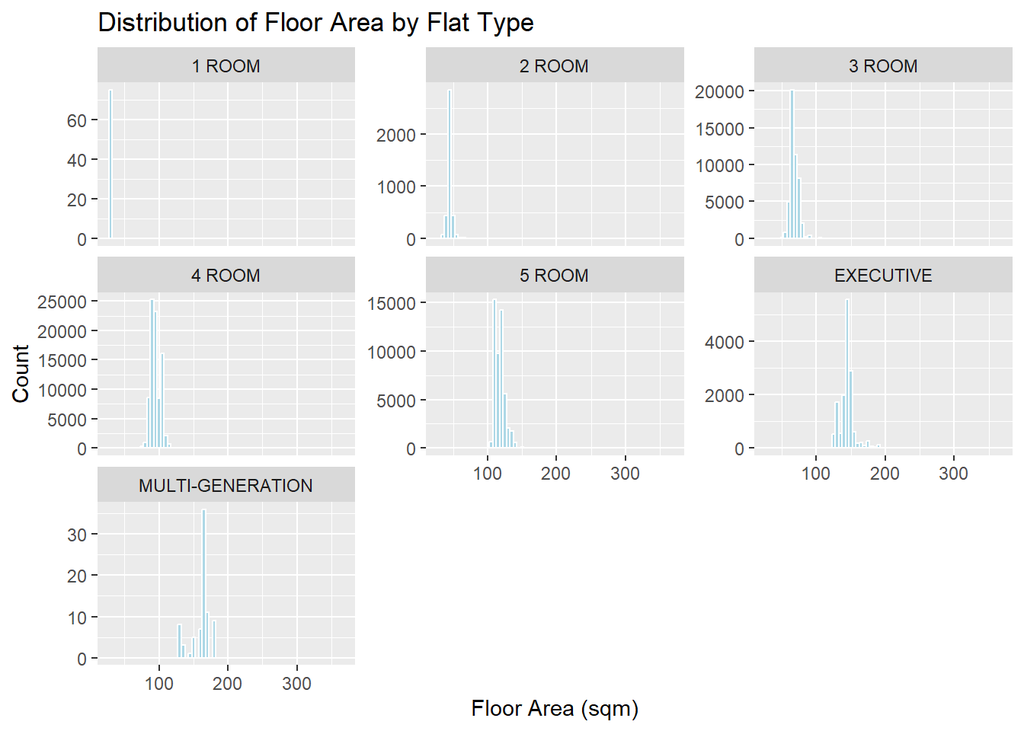

```r
flat_types <- unique(df_clean$flat_type)
ggplot(df_clean, aes(x = floor_area_sqm)) +
  geom_histogram(binwidth = 5, fill = "lightblue", color = "white") +
  facet_wrap(~flat_type, scales = "free_y") +
  labs(title = "Distribution of Floor Area by Flat Type", x = "Floor Area (sqm)", y = "Count")
```

Usually, both `flat_type` and `floor_area_sqm` would both contribute to a customer’s decision. Therefore, we cannot simply drop it. Instead, we try to add an interaction term. We use F-test to see whether it’s better to add interaction term or to simply drop `flat_type` or `floor_area_sqm`

```r
lr_interact <- lm(resale_price ~ floor_area_sqm * flat_type + remaining_lease_years +
                      flat_model_group + region + storey_median + month, data = train)
lr_sqm <- lm(resale_price ~ floor_area_sqm + remaining_lease_years + flat_model_group + region +storey_median+month, data = train)
lr_type <- lm(resale_price ~ flat_type + remaining_lease_years + flat_model_group + region +storey_median+month, data = train)

anova(lr_full, lr_sqm, lr_type, lr_interact)
```

```
## Analysis of Variance Table
##
## Model 1: resale_price ~ month + flat_type + floor_area_sqm + remaining_lease_years +
##     flat_model_group + region + storey_median
## Model 2: resale_price ~ floor_area_sqm + remaining_lease_years + flat_model_group +
##     region + storey_median + month
## Model 3: resale_price ~ flat_type + remaining_lease_years + flat_model_group +
##     region + storey_median + month
## Model 4: resale_price ~ floor_area_sqm * flat_type + remaining_lease_years +
##     flat_model_group + region + storey_median + month
##   Res.Df        RSS Df   Sum of Sq       F    Pr(>F)
## 1 179980 1.2083e+15
## 2 179986 1.2198e+15 -6 -1.1526e+13  290.15 < 2.2e-16 ***
## 3 179981 1.3301e+15  5 -1.1024e+14
## 4 179975 1.1916e+15  6  1.3853e+14 3487.33 < 2.2e-16 ***
## ---
## Signif. codes:  0 '***' 0.001 '**' 0.01 '*' 0.05 '.' 0.1 ' ' 1
```

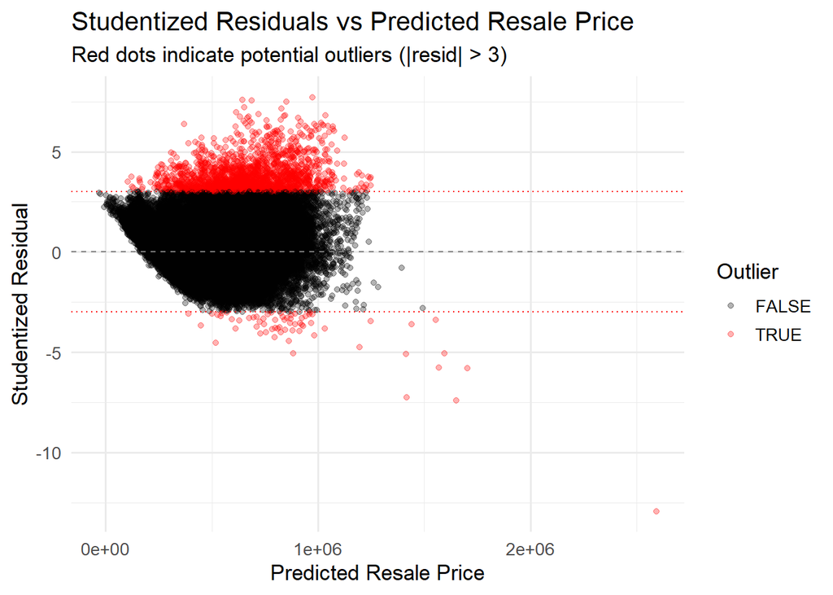

```r
fitted_vals <- predict(lr_interact)
stud_resid <- rstudent(lr_interact)

resid_df <- data.frame(fitted = fitted_vals, stud_resid = stud_resid)
resid_df <- resid_df %>%
  mutate(is_outlier = abs(stud_resid) > 3)
ggplot(resid_df, aes(x = fitted, y = stud_resid)) +
  geom_point(aes(color = is_outlier), alpha = 0.3) +
  geom_hline(yintercept = 0, linetype = "dashed", color = "gray50") +
  geom_hline(yintercept = c(-3, 3), linetype = "dotted", color = "red") +
  scale_color_manual(values = c("black", "red")) +
  labs(
    title = "Studentized Residuals vs Predicted Resale Price",
    subtitle = "Red dots indicate potential outliers (|resid| > 3)",
    x = "Predicted Resale Price",
    y = "Studentized Residual",
    color = "Outlier"
  ) +
  theme_minimal(base_size = 13)
```

```r
subset(resid_df, stud_resid < -10)
```

```
##         fitted stud_resid is_outlier
## 182188 2591791  -12.92863       TRUE
```

```r
extreme_outlier <- resid_df %>%
  filter(stud_resid < -10) %>%
  mutate(row_id = row_number())


index_to_drop <- which(resid_df$stud_resid < -10)
train[index_to_drop,]
```

```
##             month flat_type floor_area_sqm resale_price remaining_lease_years
## 182188 2024-07-01    3 ROOM       11.22302      1568000             -1.942995
##        flat_model_group  region storey_median
## 182188          Special Central     -1.137547
```

```r
train_cleaned <- train[-index_to_drop, ]
```

The studentised-residual plot indicates a generally stable distribution of studentized residuals, with most values within ±3, suggesting a good model fit. A few high-price transactions (>$1.5M) show larger residuals, potentially due to underfitting of rare flat types. The plot also exhibits mild heteroscedasticity, where variance increases with predicted values. This may motivate the use of `log(resale_price)` transformation or more flexible models such as splines or GAM.

#### Compared with the ls model without transformation

```r
fitted_price_base = predict(lr_full, newdata = test)
mse <- mean((test$resale_price - fitted_price_base)^2)
rmse <- sqrt(mse)
print(paste("RMSE on test set:", round(rmse, 2)))
```

```
## [1] "RMSE on test set: 81710.77"
```

```r
print(paste("Adjusted_R^2:", round(summary(lr_interact)$adj.r.squared,2)))
```

```
## [1] "Adjusted_R^2: 0.8"
```

### Refit the model with the interaction term

```r
lr.fit = lm(log(resale_price) ~ floor_area_sqm * flat_type + remaining_lease_years +
                      flat_model_group + region + storey_median + month, data = train)
fitted_price_log = predict(lr.fit, newdata = test)
mse <- mean((test$resale_price - exp(fitted_price_log))^2)
rmse <- sqrt(mse)
print(paste("RMSE on test set:", round(rmse, 2)))
```

```
## [1] "RMSE on test set: 74664.21"
```

```r
print(paste("Adjusted_R^2:", round(summary(lr.fit)$adj.r.squared,2)))
```

```
## [1] "Adjusted_R^2: 0.84"
```

### Residual plot for every variable

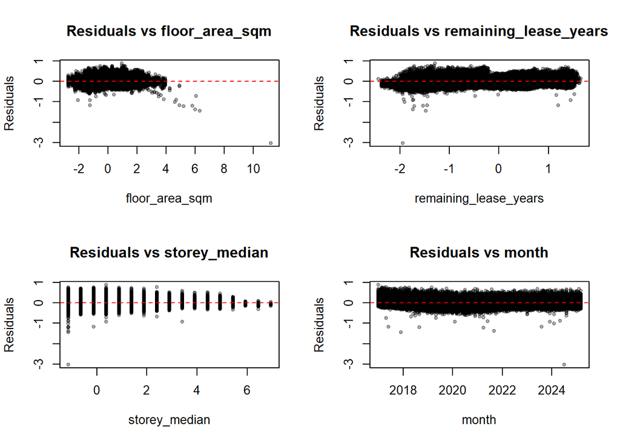

```r
predictors <- c("floor_area_sqm", "remaining_lease_years", "storey_median", "month")
par(mfrow = c(2, 2))

for (var in predictors) {
  plot(train[[var]], residuals(lr.fit),
       main = paste("Residuals vs", var),
       xlab = var, ylab = "Residuals",
       pch = 20, col = rgb(0, 0, 0, 0.3))
  abline(h = 0, col = "red", lty = 2)
}
```

### Natural Cubic Spline

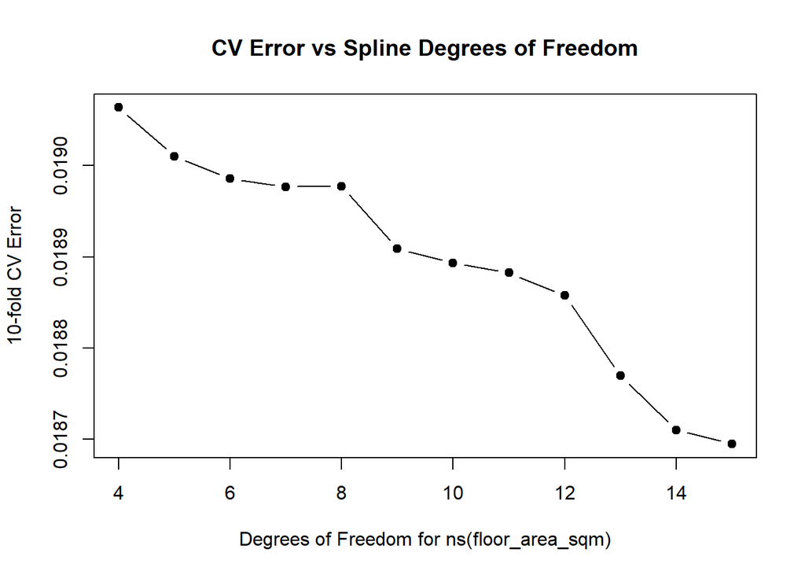

```r
get_cv_error <- function(df_val) {
  model <- glm(log(resale_price) ~ ns(floor_area_sqm, df = df_val) +
                 remaining_lease_years + flat_type + flat_model_group +
                 region + storey_median + month,
               data = train)
  cv_result <- cv.glm(train, model, K = 10)
  return(cv_result$delta[1])
}

df_list <- 4:15
cv_errors <- sapply(df_list, get_cv_error)

plot(df_list, cv_errors, type = "b", pch = 19,
     xlab = "Degrees of Freedom for ns(floor_area_sqm)",
     ylab = "10-fold CV Error",
     main = "CV Error vs Spline Degrees of Freedom")
```

Adding more degrees of freedom would have the risk of overfitting, however, there is obvious trend of stable choice of df. We choose knot = 7 to avoid underfitting and overfitting.

```r
model_ns <- lm(log(resale_price) ~ ns(floor_area_sqm, df = 7) +
                 remaining_lease_years + flat_type + flat_model_group +
                 region + storey_median + month,
               data = train)

predict_ns <- predict(model_ns, newdata=test)
```

### Smoothing Spline

```r
model_gam <- gam(log(resale_price) ~ s(floor_area_sqm) +
                   remaining_lease_years + flat_type + flat_model_group +
                   region + storey_median + month,
                 data = train)
rmse <- function(actual, predicted) {
  sqrt(mean((actual - predicted)^2))
}

pred_log_gam <- predict(model_gam, newdata = test)
pred_gam <- exp(pred_log_gam)
rmse_gam <- rmse(test$resale_price, pred_gam)
```

```r
rmse_linear <- rmse(test$resale_price, exp(fitted_price_log))
rmse_nspline <- rmse(test$resale_price, exp(predict_ns))
rmse_gam     <- rmse(test$resale_price, pred_gam)

adj_r2_base    <- summary(lr.fit)$adj.r.squared
adj_r2_nspline <- summary(model_ns)$r.sq
adj_r2_gam     <- summary(model_gam)$r.sq

result <- data.frame(
  Model = c("Linear", "Natural Spline", "GAM"),
  RMSE  = round(c(rmse_linear, rmse_nspline, rmse_gam), 2),
  Adjusted_R2 = round(c(adj_r2_base, adj_r2_nspline, adj_r2_gam), 4)
)


result
```

```
##            Model     RMSE Adjusted_R2
## 1         Linear 74664.21      0.8369
## 2 Natural Spline 74238.72      0.8382
## 3            GAM 74228.91      0.8383
```

Although natural spline and GAM models achieved marginal improvements in RMSE and adjusted R² compared to the linear baseline, the gains were minimal. Given the significantly increased model complexity and computational cost, the linear model remains a strong, interpretable, and efficient choice for predicting resale prices.

### Model Interpretation

```r
coef(lr.fit)
```

```
##                              (Intercept)
##                             9.8371022954
##                           floor_area_sqm
##                             0.2224855350
##                          flat_type2 ROOM
##                            -0.0466063577
##                          flat_type3 ROOM
##                             0.3867251366
##                          flat_type4 ROOM
##                             0.2799084991
##                          flat_type5 ROOM
##                             0.2421512505
##                       flat_typeEXECUTIVE
##                             0.2527745437
##                flat_typeMULTI-GENERATION
##                             0.1449631653
##                    remaining_lease_years
##                             0.1165441189
##               flat_model_groupMaisonette
##                             0.1602350746
##                  flat_model_groupModel A
##                            -0.0321920870
##                    flat_model_groupOther
##                             0.0645807069
##                  flat_model_groupPremium
##                             0.0053458223
##                  flat_model_groupSpecial
##                             0.2095511503
##                               regionEast
##                            -0.1859906280
##                              regionNorth
##                            -0.3644692800
##                         regionNorth-East
##                            -0.2642618792
##                               regionWest
##                            -0.3103261106
##                            storey_median
##                             0.0577289491
##                                    month
##                             0.0001722097
##           floor_area_sqm:flat_type2 ROOM
##                            -0.0743597385
##           floor_area_sqm:flat_type3 ROOM
##                             0.1093591942
##           floor_area_sqm:flat_type4 ROOM
##                            -0.0893059142
##           floor_area_sqm:flat_type5 ROOM
##                             0.0034248845
##        floor_area_sqm:flat_typeEXECUTIVE
##                            -0.0416348994
## floor_area_sqm:flat_typeMULTI-GENERATION
##                                       NA
```

```r
coef(model_ns)
```

```
##                 (Intercept) ns(floor_area_sqm, df = 7)1
##                9.2187160966                0.8245736686
## ns(floor_area_sqm, df = 7)2 ns(floor_area_sqm, df = 7)3
##                0.8479168483                0.9096078731
## ns(floor_area_sqm, df = 7)4 ns(floor_area_sqm, df = 7)5
##                0.9710184101                1.7316042684
## ns(floor_area_sqm, df = 7)6 ns(floor_area_sqm, df = 7)7
##                2.1383006045                1.3792266875
##       remaining_lease_years             flat_type2 ROOM
##                0.1192081885                0.0283032856
##             flat_type3 ROOM             flat_type4 ROOM
##                0.0164172940                0.0105174321
##             flat_type5 ROOM          flat_typeEXECUTIVE
##                0.0037920144               -0.0562604492
##   flat_typeMULTI-GENERATION  flat_model_groupMaisonette
##               -0.0721635896                0.1482638704
##     flat_model_groupModel A       flat_model_groupOther
##               -0.0400410073                0.0588088530
##     flat_model_groupPremium     flat_model_groupSpecial
##                0.0015804811                0.2285101891
##                  regionEast                 regionNorth
##               -0.1921070020               -0.3685808948
##            regionNorth-East                  regionWest
##               -0.2681275102               -0.3150080735
##               storey_median                       month
##                0.0574499751                0.0001728543
```

```r
coef(model_gam)
```

```
##                (Intercept)      remaining_lease_years
##              10.0274428840               0.1168894114
##            flat_type2 ROOM            flat_type3 ROOM
##               0.0895574346               0.0777497947
##            flat_type4 ROOM            flat_type5 ROOM
##               0.0736181749               0.0690078343
##         flat_typeEXECUTIVE  flat_typeMULTI-GENERATION
##               0.0148900367              -0.0147657171
## flat_model_groupMaisonette    flat_model_groupModel A
##               0.1639042179              -0.0370067007
##      flat_model_groupOther    flat_model_groupPremium
##               0.0665939320               0.0038217976
##    flat_model_groupSpecial                 regionEast
##               0.2308634402              -0.1918081924
##                regionNorth           regionNorth-East
##              -0.3693171641              -0.2692276151
##                 regionWest              storey_median
##              -0.3154370504               0.0573599179
##                      month        s(floor_area_sqm).1
##               0.0001723679              -0.2805979109
##        s(floor_area_sqm).2        s(floor_area_sqm).3
##               0.2393201590               0.2137892426
##        s(floor_area_sqm).4        s(floor_area_sqm).5
##              -0.1814907579               0.1593964068
##        s(floor_area_sqm).6        s(floor_area_sqm).7
##               0.2045962091              -0.1570737332
##        s(floor_area_sqm).8        s(floor_area_sqm).9
##               1.2080410057               0.0713280877
```

### Hypothesis Testingn (Q2)

```r
summary(lr.fit)
```

```
##
## Call:
## lm(formula = log(resale_price) ~ floor_area_sqm * flat_type +
##     remaining_lease_years + flat_model_group + region + storey_median +
##     month, data = train)
##
## Residuals:
##      Min       1Q   Median       3Q      Max
## -3.02809 -0.08963 -0.00728  0.07889  0.88515
##
## Coefficients: (1 not defined because of singularities)
##                                            Estimate Std. Error  t value
## (Intercept)                               9.837e+00  8.607e-02  114.295
## floor_area_sqm                            2.225e-01  3.069e-02    7.248
## flat_type2 ROOM                          -4.661e-02  9.292e-02   -0.502
## flat_type3 ROOM                           3.867e-01  8.584e-02    4.505
## flat_type4 ROOM                           2.799e-01  8.578e-02    3.263
## flat_type5 ROOM                           2.422e-01  8.581e-02    2.822
## flat_typeEXECUTIVE                        2.528e-01  8.599e-02    2.940
## flat_typeMULTI-GENERATION                 1.450e-01  1.679e-01    0.863
## remaining_lease_years                     1.165e-01  5.410e-04  215.415
## flat_model_groupMaisonette                1.602e-01  4.217e-03   37.998
## flat_model_groupModel A                  -3.219e-02  1.254e-03  -25.676
## flat_model_groupOther                     6.458e-02  3.912e-03   16.509
## flat_model_groupPremium                   5.346e-03  1.345e-03    3.976
## flat_model_groupSpecial                   2.096e-01  4.934e-03   42.471
## regionEast                               -1.860e-01  1.197e-03 -155.339
## regionNorth                              -3.645e-01  1.187e-03 -307.166
## regionNorth-East                         -2.643e-01  1.086e-03 -243.402
## regionWest                               -3.103e-01  1.075e-03 -288.684
## storey_median                             5.773e-02  3.560e-04  162.155
## month                                     1.722e-04  3.899e-07  441.699
## floor_area_sqm:flat_type2 ROOM           -7.436e-02  3.496e-02   -2.127
## floor_area_sqm:flat_type3 ROOM            1.094e-01  3.080e-02    3.551
## floor_area_sqm:flat_type4 ROOM           -8.931e-02  3.076e-02   -2.903
## floor_area_sqm:flat_type5 ROOM            3.425e-03  3.079e-02    0.111
## floor_area_sqm:flat_typeEXECUTIVE        -4.163e-02  3.084e-02   -1.350
## floor_area_sqm:flat_typeMULTI-GENERATION         NA         NA       NA
##                                          Pr(>|t|)
## (Intercept)                               < 2e-16 ***
```

[output cut: 16 more lines]

```
## regionWest                                < 2e-16 ***
## storey_median                             < 2e-16 ***
## month                                     < 2e-16 ***
## floor_area_sqm:flat_type2 ROOM           0.033420 *
## floor_area_sqm:flat_type3 ROOM           0.000384 ***
## floor_area_sqm:flat_type4 ROOM           0.003695 **
## floor_area_sqm:flat_type5 ROOM           0.911431
## floor_area_sqm:flat_typeEXECUTIVE        0.176940
## floor_area_sqm:flat_typeMULTI-GENERATION       NA
## ---
## Signif. codes:  0 '***' 0.001 '**' 0.01 '*' 0.05 '.' 0.1 ' ' 1
##
## Residual standard error: 0.1383 on 179975 degrees of freedom
## Multiple R-squared:  0.8369, Adjusted R-squared:  0.8369
## F-statistic: 3.848e+04 on 24 and 179975 DF,  p-value: < 2.2e-16
```

```r
summary(model_ns)
```

```
##
## Call:
## lm(formula = log(resale_price) ~ ns(floor_area_sqm, df = 7) +
##     remaining_lease_years + flat_type + flat_model_group + region +
##     storey_median + month, data = train)
##
## Residuals:
##      Min       1Q   Median       3Q      Max
## -1.17184 -0.08944 -0.00747  0.07834  0.88947
##
## Coefficients:
##                               Estimate Std. Error  t value Pr(>|t|)
## (Intercept)                  9.219e+00  1.786e-02  516.234  < 2e-16 ***
## ns(floor_area_sqm, df = 7)1  8.246e-01  1.341e-02   61.489  < 2e-16 ***
## ns(floor_area_sqm, df = 7)2  8.479e-01  1.460e-02   58.061  < 2e-16 ***
## ns(floor_area_sqm, df = 7)3  9.096e-01  1.419e-02   64.117  < 2e-16 ***
## ns(floor_area_sqm, df = 7)4  9.710e-01  1.456e-02   66.680  < 2e-16 ***
## ns(floor_area_sqm, df = 7)5  1.732e+00  1.381e-02  125.362  < 2e-16 ***
## ns(floor_area_sqm, df = 7)6  2.138e+00  4.619e-02   46.289  < 2e-16 ***
## ns(floor_area_sqm, df = 7)7  1.379e+00  7.439e-02   18.541  < 2e-16 ***
## remaining_lease_years        1.192e-01  5.791e-04  205.860  < 2e-16 ***
## flat_type2 ROOM              2.830e-02  1.839e-02    1.539  0.12382
## flat_type3 ROOM              1.642e-02  2.174e-02    0.755  0.45015
## flat_type4 ROOM              1.052e-02  2.151e-02    0.489  0.62483
## flat_type5 ROOM              3.792e-03  2.170e-02    0.175  0.86125
## flat_typeEXECUTIVE          -5.626e-02  2.200e-02   -2.558  0.01054 *
## flat_typeMULTI-GENERATION   -7.216e-02  2.753e-02   -2.621  0.00876 **
## flat_model_groupMaisonette   1.483e-01  4.119e-03   35.995  < 2e-16 ***
## flat_model_groupModel A     -4.004e-02  1.271e-03  -31.503  < 2e-16 ***
## flat_model_groupOther        5.881e-02  3.873e-03   15.184  < 2e-16 ***
## flat_model_groupPremium      1.580e-03  1.350e-03    1.171  0.24166
## flat_model_groupSpecial      2.285e-01  4.930e-03   46.349  < 2e-16 ***
## regionEast                  -1.921e-01  1.200e-03 -160.095  < 2e-16 ***
## regionNorth                 -3.686e-01  1.188e-03 -310.301  < 2e-16 ***
## regionNorth-East            -2.681e-01  1.090e-03 -246.026  < 2e-16 ***
## regionWest                  -3.150e-01  1.076e-03 -292.640  < 2e-16 ***
## storey_median                5.745e-02  3.547e-04  161.954  < 2e-16 ***
## month                        1.729e-04  3.906e-07  442.492  < 2e-16 ***
## ---
## Signif. codes:  0 '***' 0.001 '**' 0.01 '*' 0.05 '.' 0.1 ' ' 1
##
## Residual standard error: 0.1377 on 179974 degrees of freedom
## Multiple R-squared:  0.8382, Adjusted R-squared:  0.8382
## F-statistic: 3.73e+04 on 25 and 179974 DF,  p-value: < 2.2e-16
```

```r
summary(model_gam)
```

```
##
## Family: gaussian
## Link function: identity
##
## Formula:
## log(resale_price) ~ s(floor_area_sqm) + remaining_lease_years +
##     flat_type + flat_model_group + region + storey_median + month
##
## Parametric coefficients:
##                              Estimate Std. Error  t value Pr(>|t|)
## (Intercept)                 1.003e+01  2.325e-02  431.272  < 2e-16 ***
## remaining_lease_years       1.169e-01  5.427e-04  215.393  < 2e-16 ***
## flat_type2 ROOM             8.956e-02  1.894e-02    4.727 2.28e-06 ***
## flat_type3 ROOM             7.775e-02  2.241e-02    3.469 0.000522 ***
## flat_type4 ROOM             7.362e-02  2.214e-02    3.325 0.000884 ***
## flat_type5 ROOM             6.901e-02  2.235e-02    3.087 0.002020 **
## flat_typeEXECUTIVE          1.489e-02  2.276e-02    0.654 0.512879
## flat_typeMULTI-GENERATION  -1.477e-02  2.815e-02   -0.524 0.599960
## flat_model_groupMaisonette  1.639e-01  4.465e-03   36.712  < 2e-16 ***
## flat_model_groupModel A    -3.701e-02  1.242e-03  -29.792  < 2e-16 ***
## flat_model_groupOther       6.659e-02  3.940e-03   16.902  < 2e-16 ***
## flat_model_groupPremium     3.822e-03  1.339e-03    2.855 0.004309 **
## flat_model_groupSpecial     2.309e-01  4.944e-03   46.693  < 2e-16 ***
## regionEast                 -1.918e-01  1.199e-03 -159.973  < 2e-16 ***
## regionNorth                -3.693e-01  1.188e-03 -310.919  < 2e-16 ***
## regionNorth-East           -2.692e-01  1.089e-03 -247.286  < 2e-16 ***
## regionWest                 -3.154e-01  1.075e-03 -293.300  < 2e-16 ***
## storey_median               5.736e-02  3.547e-04  161.730  < 2e-16 ***
## month                       1.724e-04  3.884e-07  443.839  < 2e-16 ***
## ---
## Signif. codes:  0 '***' 0.001 '**' 0.01 '*' 0.05 '.' 0.1 ' ' 1
##
## Approximate significance of smooth terms:
##                     edf Ref.df    F p-value
## s(floor_area_sqm) 8.978      9 3375  <2e-16 ***
## ---
## Signif. codes:  0 '***' 0.001 '**' 0.01 '*' 0.05 '.' 0.1 ' ' 1
##
## R-sq.(adj) =  0.838   Deviance explained = 83.8%
## GCV = 0.018967  Scale est. = 0.018964  n = 180000
```

```r
anova(lr.fit)
```

```
## Analysis of Variance Table
##
## Response: log(resale_price)
##                              Df Sum Sq Mean Sq   F value    Pr(>F)
## floor_area_sqm                1 8356.6  8356.6 436921.24 < 2.2e-16 ***
## flat_type                     6  768.9   128.2   6700.72 < 2.2e-16 ***
## remaining_lease_years         1 1094.5  1094.5  57224.84 < 2.2e-16 ***
## flat_model_group              5  357.6    71.5   3739.30 < 2.2e-16 ***
## region                        4 2643.8   660.9  34557.53 < 2.2e-16 ***
## storey_median                 1  586.3   586.3  30653.43 < 2.2e-16 ***
## month                         1 3771.9  3771.9 197210.75 < 2.2e-16 ***
## floor_area_sqm:flat_type      5   83.5    16.7    873.05 < 2.2e-16 ***
## Residuals                179975 3442.2     0.0
## ---
## Signif. codes:  0 '***' 0.001 '**' 0.01 '*' 0.05 '.' 0.1 ' ' 1
```

```r
anova(model_ns)
```

```
## Analysis of Variance Table
##
## Response: log(resale_price)
##                                Df Sum Sq Mean Sq   F value    Pr(>F)
## ns(floor_area_sqm, df = 7)      7 9354.2  1336.3  70435.47 < 2.2e-16 ***
## remaining_lease_years           1  954.0   954.0  50286.66 < 2.2e-16 ***
## flat_type                       6   64.4    10.7    565.45 < 2.2e-16 ***
## flat_model_group                5  366.4    73.3   3862.93 < 2.2e-16 ***
## region                          4 2679.5   669.9  35308.61 < 2.2e-16 ***
## storey_median                   1  557.4   557.4  29380.40 < 2.2e-16 ***
## month                           1 3714.7  3714.7 195799.02 < 2.2e-16 ***
## Residuals                  179974 3414.5     0.0
## ---
## Signif. codes:  0 '***' 0.001 '**' 0.01 '*' 0.05 '.' 0.1 ' ' 1
```

```r
anova(model_gam)
```

```
##
## Family: gaussian
## Link function: identity
##
## Formula:
## log(resale_price) ~ s(floor_area_sqm) + remaining_lease_years +
##     flat_type + flat_model_group + region + storey_median + month
##
## Parametric Terms:
##                       df         F p-value
## remaining_lease_years  1  46394.03  <2e-16
## flat_type              6     42.58  <2e-16
## flat_model_group       5   1109.62  <2e-16
## region                 4  30100.69  <2e-16
## storey_median          1  26156.61  <2e-16
## month                  1 196992.81  <2e-16
##
## Approximate significance of smooth terms:
##                     edf Ref.df    F p-value
## s(floor_area_sqm) 8.978  9.000 3375  <2e-16
```